# Live 2021 Election Turnout Tracker

Welcome to the [Sixty-Six Wards](https://sixtysixwards.com/) Turnout Tracker! Voters across Philadelphia are sharing their turnout to support citizen science.

> First, vote! Then, share your division and Voter Number at bit.ly/sixtysixturnout .

## Live Results

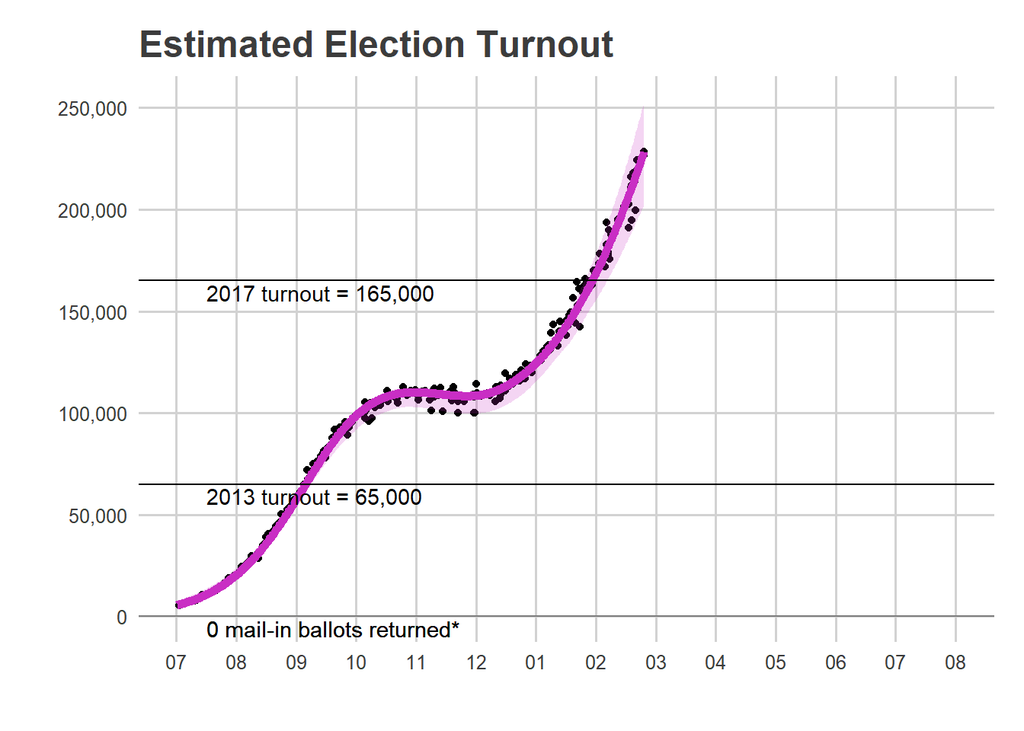

NOTE: The above mail counts are received from the Commissioners’ Office. Some mail-ins that have already arrived are probably not included in this projection. In addition, ballots postmarked today that haven’t arrived yet are not included.

## Maps

I use historic correlations among divisions’ turnout to estimate turnout in the divisions with no data yet. I simultaneously estimate (1) the overall city-wide turnout, (2) divisions’ over-/under-performance, and (3) the city-wide time pattern of voting. See the [Methodology](https://htmlpreview.github.io/?https://github.com/jtannen/turnout_tracker/blob/master/methodology.html).

### Total Turnout (In-Person + Mail-In)

[interactive chart not shown]

```
## [1] ""
```

### In-Person Turnout

[interactive chart not shown]

```
## [1] ""
```

```
## [1] ""
```

### Raw Responses (for debugging)

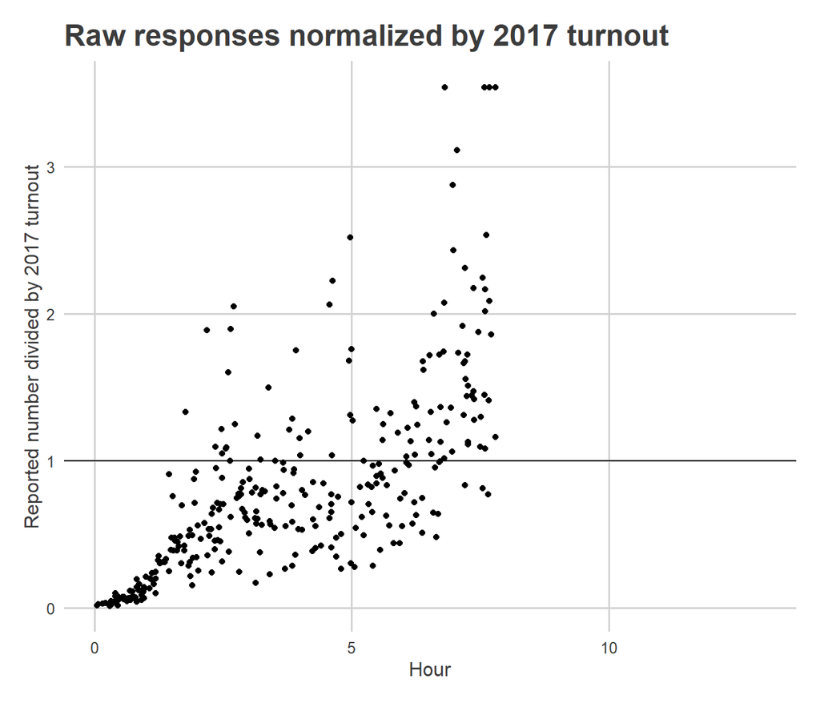

### Submissions

[interactive chart not shown]

## Data Tables

For those of you who like tables with numbers.

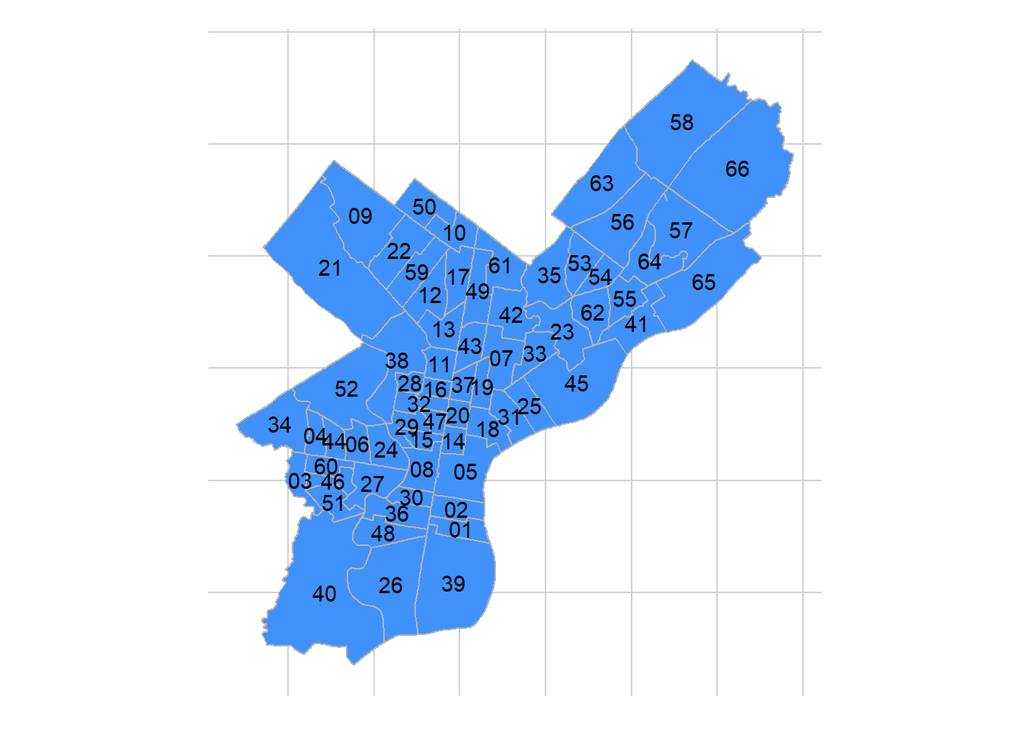

**Estimated Turnout by Ward**

[output not shown]

## Raw Submissions

**Submitted Data**

| Time of Vote | Precinct | Voter Number |
| --- | --- | --- |
| 1:48 PM | 2127 | 115 |
| 1:04 PM | 6623 | 76 |
| 1:35 PM | 4820 | 67 |
| 10:54 AM | 3930 | 62 |
| 7:13 AM | 5224 | 4 |
| 11:42 AM | 1502 | 122 |
| 10:51 AM | 3632 | 58 |
| 7:19 AM | 3704 | 2 |
| 12:10 PM | 6020 | 79 |
| 7:46 AM | 5001 | 11 |
| 8:36 AM | 1315 | 25 |
| 10:53 AM | 4508 | 33 |
| 11:42 AM | 3009 | 79 |
| 10:43 AM | 6507 | 103 |
| 7:20 AM | 3411 | 3 |
| 12:37 PM | 6213 | 65 |
| 10:40 AM | 6608 | 103 |
| 12:36 PM | 5604 | 46 |
| 7:24 AM | 4202 | 3 |
| 11:34 AM | 2229 | 113 |
| 7:27 AM | 4909 | 9 |
| 11:15 AM | 3414 | 95 |
| 9:27 AM | 3201 | 29 |
| 2:15 PM | 6608 | 179 |
| 11:00 AM | 2311 | 47 |
| 1:13 PM | 4007 | 102 |
| 12:29 PM | 2818 | 61 |
| 2:35 PM | 5628 | 100 |
| 11:48 AM | 3926 | 44 |
| 7:49 AM | 4104 | 9 |

[output cut: 289 more lines]

**Download the csvs**: - [Raw Submissions](https://jtannen.github.io/raw_data.csv) - [Division Predictions](https://jtannen.github.io/precinct_turnout_philadelphia.csv)